# Научная презентация 8

Дисциплина:Операционные системы

Алехин Давид Андреевич

Российский университет дружбы народов, Москва, Россия

Математический институт имени Никольского, Москва, Россия

06.03.25

# Информация

## Докладчик

- Алехин Давид Андреевич
- Студент
- Студент НММбд-01-24
- Российский университет дружбы народов
- 1132246830@pfur.ru
- https://github.com/trustdef

[figure not shown]

# Элементы презентации

## Актуальность

- Важно уметь работать с файловой системой.

## Цели и задачи

- Ознакомление с файловой системой Linux, её структурой, именами и содержанием каталогов. Приобретение практических навыков по применению команд для работы с файлами и каталогами, по управлению процессами, по проверке использования диска и обслуживанию файловой системы.

## Материалы и методы

- fedora-linux

## Содержание исследования

Запишем в файл file.txt названия файлов, содержащихся в каталоге /etc. Допишем в этот же файл названия файлов, содержащихся в нашем домашнем каталоге (рис. [-@fig:001]).

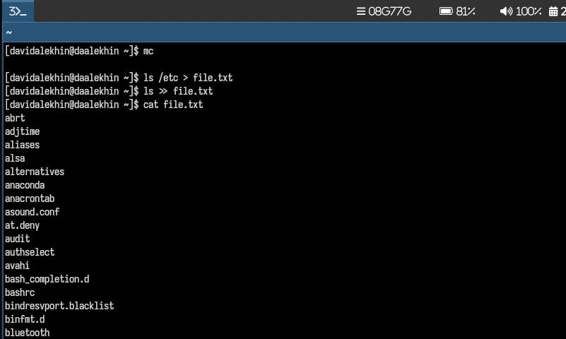

etc/davidalekhin

## Содержание исследования

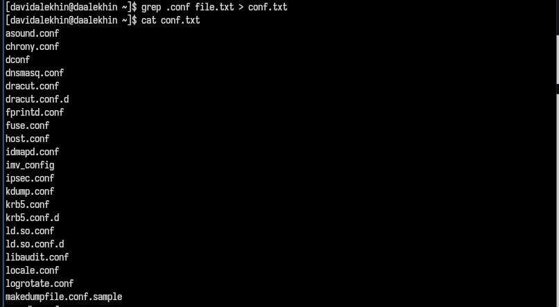

.conf

## Содержание исследования

Определили, какие файлы в нашем домашнем каталоге имеют имена, начинавшиеся с символа c? (рис. [-@fig:003]).

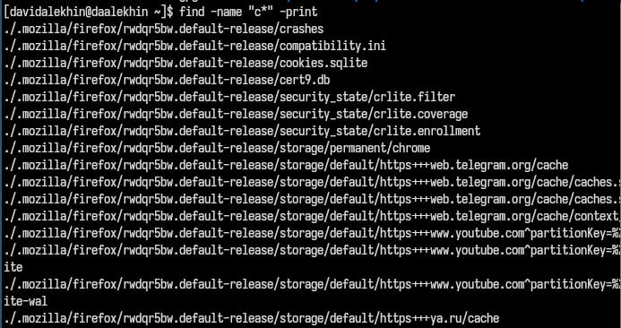

c

## Содержание исследования

Выведем на экран (постранично) имена файлов из каталога /etc, начинающиеся с символа h (рис. [-@fig:004]).

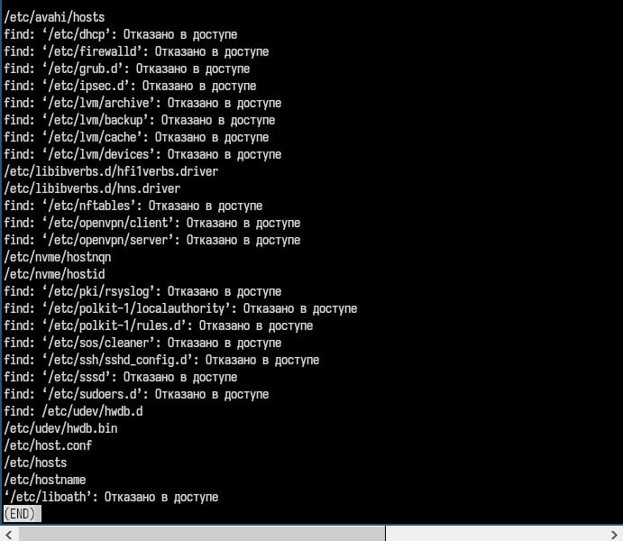

etc h*

## Содержание исследования

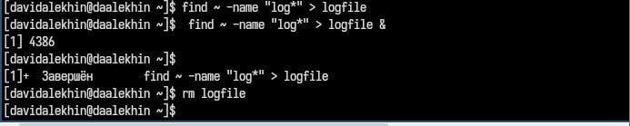

log

## Содержание исследования

Запустили из консоли в фоновом режиме редактор gedit. Определили идентификатор процесса gedit, используя команду ps, конвейер и фильтр grep. Прочитали справку (man) команды kill, после чего используйте её для завершения процесса gedit (рис. [-@fig:006]).

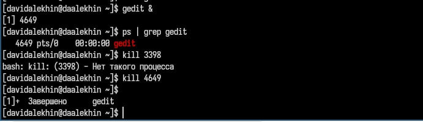

gedit

## Содержание исследования

Выполним команды df и du, предварительно получив более подробную информацию об этих командах, с помощью команды man (рис. [-@fig:007], [-@fig:008]).

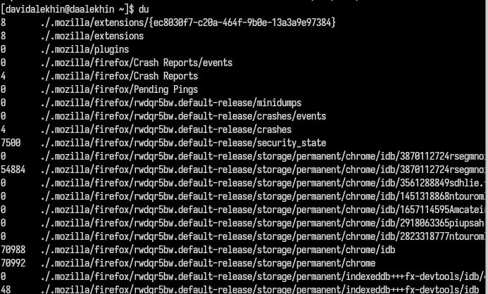

## Содержание исследования

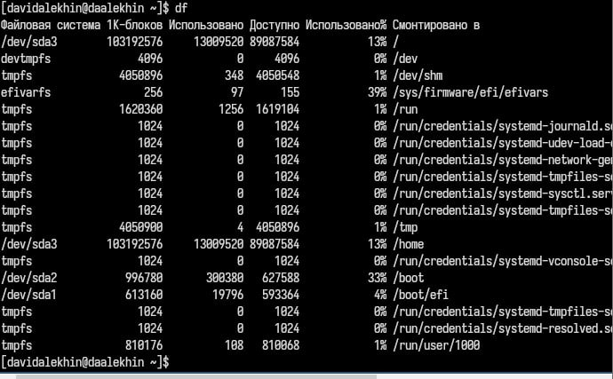

## Содержание исследования

Воспользовавшись справкой команды find, вывести имена всех директорий, имеющихся в нашем домашнем каталоге (рис. [-@fig:009]).

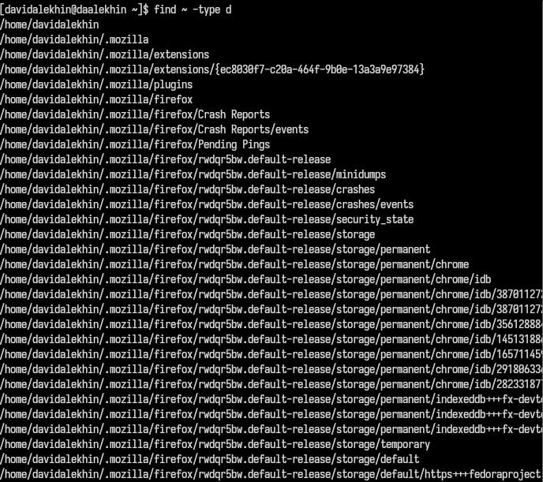

find

## Результаты

В данной работе мы ознакомились с инструментами поиска файлов и фильтрации текстовых данных. А также приобрели практические навыки по управлению процессами.

## Итоговый слайд

В теории, теория и практика неразделимы. На практике это не так. Yoggi Berra